# week2

# Chapter 1. 모델링을 위한 전처리

### 문제 0 기본 세팅. tidyverse, data.table, VIM 패키지를 부른 후, setwd로 ‘data.csv’가 있는 폴더로 경로를 설정하고, fread로 ‘data.csv’를 불러오세요.

```r
library(tidyverse)
library(data.table)
library(VIM)
setwd("C:/Users/jhlee/Documents/package_week2")
mydata <- fread("data.csv")
```

### 문제 1. ‘2’로 끝나는 변수를 모두 제거하세요. (단순히 변수의 이름 또는 인덱스 열거를 통한 제거가 아닌 적절한 함수를 사용할 것) (‘2’로 끝나는 변수는 2016년 기준 값이고, ‘1’은 2017년 기준입니다. 정확한 모델링을 위해서는 이를 모두 고려해야 하지만, 전처리 방법 학습 및 간단한 모델링을 위해 2017년 기준 변수만 사용하도록 하겠습니다.)

```r
mydata <- dplyr::select(mydata, -contains("2"))
```

### 문제 2. ‘VIM’ 패키지를 이용하여 다음과 같이 시각화 한 후 간단히 해석해 보세요. (아래처럼 변수가 모두 출력이 안될수 있습니다. 사용 색: pink, lightyellow)

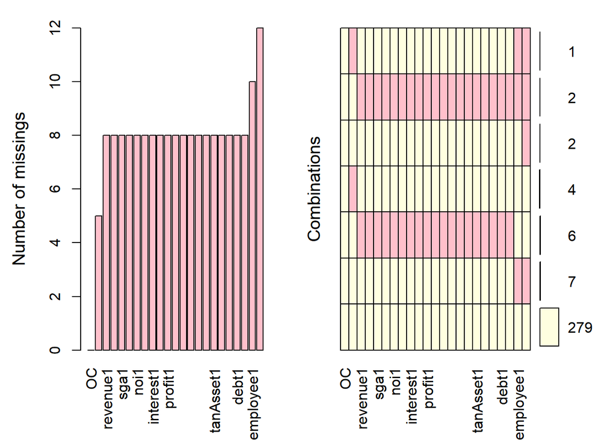

```r
VIM::aggr(mydata, prop = FALSE, numbers = TRUE, col = c("lightyellow","pink"))
```

### 문제 3-1 NA imputation. 숫자 데이터의 NA값을 mean imputation을 통해 채우세요. (lapply 이용할 것)

```r
mydata$profit1 <- as.numeric(mydata$profit1)
mydata$noi1 <- as.numeric(mydata$noi1)
mydata$noe1 <- as.numeric(mydata$noe1)
mydata$interest1 <- as.numeric(mydata$interest1)
mydata$noe1 <- as.numeric(mydata$noe1)
mydata$ctax1 <- as.numeric(mydata$ctax1)
mydata$liquidAsset1 <- as.numeric(mydata$liquidAsset1)
mydata$quickAsset1 <- as.numeric(mydata$quickAsset1)
mydata$debt1 <- as.numeric(mydata$debt1)



mydata <- data.frame(lapply(mydata, function(x) {
  if(is.numeric(x)) ifelse(is.na(x), mean(x, na.rm = T), x) else x}))
```

### 문제 3-2 NA imputation. 범주 데이터의 NA값을 mode imputation을 통해 채우세요.

```r
Mode <- function(x) {
  ux <- unique(x)
  ux[which.max(tabulate(match(x, ux)))]
}



mydata <- data.frame(lapply(mydata, function(x) {
  if(is.factor(x) | is.character(x)) ifelse(is.na(x), Mode(x), x) else x}))


mydata$OC <- as.factor(mydata$OC)
mydata$ownerChange <- as.factor(mydata$ownerChange)
```

### 문제 4. 변수 ‘OC(병원 개/폐업 여부)’를 타겟 변수로 사용하기 위해 “open”을 1, “close”를 0으로 바꾸세요.

```r
mydata$OC <- ifelse(mydata$OC == "open", 1, 0)
mydata$OC <- as.factor(mydata$OC)
```

### 문제 5. 숫자 데이터 중 integer 자료형인 경우 num(numeric) 자료형으로 바꾸세요. (lapply 이용할 것)

```r
mydata <- data.frame(lapply(mydata, function(x) {
  if(is.integer(x)) as.numeric(x, round = 0) else x}))
```

# Chpater2. 분류모델

### 문제 1. 앞서 전처리한 데이터를 createDataPartition으로 7:3으로 train과 validation set으로 나누세요.

```r
library(caret)
library(MLmetrics)
library(randomForest)
set.seed(1234)
val_index <- createDataPartition(
  mydata$OC, p = 0.3, list = FALSE
)

val_set <- mydata[val_index,]
train_set <- mydata[-val_index,]
```

### 문제 2 Hold-out. train 데이터의 모든 변수를 이용하여 ‘OC’를 타겟으로 하는 로지스틱 회귀를 만들고 validation set의 Accuracy값을 구하세요.

```r
lg <- glm(OC ~ .,family = "binomial", data = train_set,maxit = 100)
predicted_value <- predict(lg, newdata = val_set, type = "response")

result <- ifelse(predicted_value >= 0.5, 1, 0)
result <- as.factor(result)
confusionMatrix(result,val_set$OC, positive = "1")
```

```
## Confusion Matrix and Statistics
##
##           Reference
## Prediction  0  1
##          0  0  7
##          1  5 79
##
##                Accuracy : 0.8681
##                  95% CI : (0.781, 0.93)
##     No Information Rate : 0.9451
##     P-Value [Acc > NIR] : 0.9986
##
##                   Kappa : -0.0685
##
##  Mcnemar's Test P-Value : 0.7728
##
##             Sensitivity : 0.9186
##             Specificity : 0.0000
##          Pos Pred Value : 0.9405
##          Neg Pred Value : 0.0000
##              Prevalence : 0.9451
##          Detection Rate : 0.8681
##    Detection Prevalence : 0.9231
##       Balanced Accuracy : 0.4593
##
##        'Positive' Class : 1
##
```

### 문제 3 Feature selection & Hold-out. 변수선택법 중 단계적 선택법을 이용하여 변수를 선택하고, 선택된 변수들로 로지스틱 회귀를 만들어 validation set의 Accuracy값을 구하세요.

```r
# emptyset <- glm(OC ~ 1, family = binomial, data = train_set)
# step_vs <- step(emptyset, direction = "both", scope = list(lower = formula(emptyset), upper = formula(lg)),trace = 0)
#원래 위와 같이 해서 되어야 하는데... 데이터 전처리가 이상하게 된거 같아서 저렇게 하면 결과가 안나옵니당..

step_vs <- step(lg, direction = "both", trace = 0)
```

[output not shown]

[output cut: 324 more lines]

[output not shown]

```r
#그래서 위와 같이 잘못된 문법으로 일단 돌리고 내겠습니다..
predicted_value2 <- predict(step_vs,newdata = val_set, type = "response")

result2 <- ifelse(predicted_value2 > 0.5, 1, 0)
result2 <- as.factor(result2)
confusionMatrix(val_set$OC,result2)
```

```
## Confusion Matrix and Statistics
##
##           Reference
## Prediction  0  1
##          0  0  5
##          1  5 81
##
##                Accuracy : 0.8901
##                  95% CI : (0.8072, 0.946)
##     No Information Rate : 0.9451
##     P-Value [Acc > NIR] : 0.9887
##
##                   Kappa : -0.0581
##
##  Mcnemar's Test P-Value : 1.0000
##
##             Sensitivity : 0.00000
##             Specificity : 0.94186
##          Pos Pred Value : 0.00000
##          Neg Pred Value : 0.94186
##              Prevalence : 0.05495
##          Detection Rate : 0.00000
##    Detection Prevalence : 0.05495
##       Balanced Accuracy : 0.47093
##
##        'Positive' Class : 0
##
```

### 문제 4. mtry에 대한 그리드서치를 위해 expand.grid를 이용하여 다음과 같은 데이터 프레임을 만드세요. (데이터 프레임 명: acc_rf)

```r
acc_rf <- expand.grid(mtry =c(3,4,5), acc = NA)

acc_rf
```

```
##   mtry acc
## 1    3  NA
## 2    4  NA
## 3    5  NA
```

### 문제 5. 로지스틱회귀에서 선택된 변수들로 랜덤포레스트에 대한 5-fold CV 그리드서치를 진행하여 acc_rf의 acc 변수에 해당 Accuracy값을 넣으세요. (ntree 파라미터를 10으로 설정하고, 이중 for문을 이용하여 직접 코드를 짤 것)

```r
folds <- createFolds(mydata$OC, k=5)


for(i in 1:3){
  cvacc <- NULL
  for(k in 1:5){
    cv_train = mydata[-folds[[k]],]
    cv_test = mydata[folds[[k]],]

    mymodel <- randomForest(OC ~ revenue1 + salescost1 + sga1 + noi1 + noe1 + interest1 + profit1 + liquidAsset1 + quickAsset1 + receivableS1 + nonCAsset1 + tanAsset1 + surplus1 + ownerChange, mtry = acc_rf[i,1], data = cv_train, ntree = 10, na.action = na.omit)
    pred<- predict(mymodel, cv_test)
    cm <- confusionMatrix(pred, cv_test$OC)
    co <- cm$overall
    cvacc[k]<- co[1]
  }
  acc_rf[i,2] <- mean(cvacc)
}
```

### 문제 6. acc_rf에서 가장 높은 Accuracy값의 행을 출력하세요.

```r
acc_rf %>%
  filter(acc == max(acc))
```

```
##   mtry       acc
## 1    4 0.9368306
```

### 제 7. 가장 좋은 파라미터 조합으로 랜덤포레스트 모델을 학습시킨 후, varImpPlot과 ggplot을 이용해 다음과 같이시각화 하여 이를 기반으로 모델을 해석해주세요. (사용 색: pink)

```r
plotmodel <- randomForest(formula = OC ~ revenue1 + salescost1 + sga1 + noi1 + noe1 +
    interest1 + profit1 + liquidAsset1 + quickAsset1 + receivableS1 +
    inventoryAsset1 + nonCAsset1 + tanAsset1 + debt1 + employee1, mtry = 4, data = mydata, ntree = 10, na.action = na.omit, importance = TRUE)


importance(plotmodel)
```

```
##                          0            1 MeanDecreaseAccuracy MeanDecreaseGini
## revenue1         0.4984448  2.413582408            2.3710170         4.447016
## salescost1       0.0000000  0.268163943            0.3090233         1.227143
## sga1            -1.0540926  1.414853198            1.3530407         2.980446
## noi1             0.0000000  1.054092553            1.0540926         1.130649
## noe1            -1.0540926 -0.269112395           -0.4435538         2.195887
## interest1        1.0540926  1.649903722            1.7924246         1.461735
## profit1          0.0000000  1.772723601            1.7925863         3.819768
## liquidAsset1    -1.0540926  1.635105525            1.6981727         1.642271
## quickAsset1     -1.0540926  0.842296358            0.7844232         1.374303
## receivableS1     1.0540926 -1.268390607           -0.9829491         1.165138
## inventoryAsset1 -1.0540926 -0.008013776           -0.5449443         1.184739
## nonCAsset1       0.0000000  1.581138830            1.5810572         1.178270
## tanAsset1       -1.5613491  1.839250892            1.5910410         1.578255
## debt1            0.4517540  0.852264669            0.8708028         2.378628
## employee1       -1.5730345  0.279501828           -0.1886212         1.037462
```

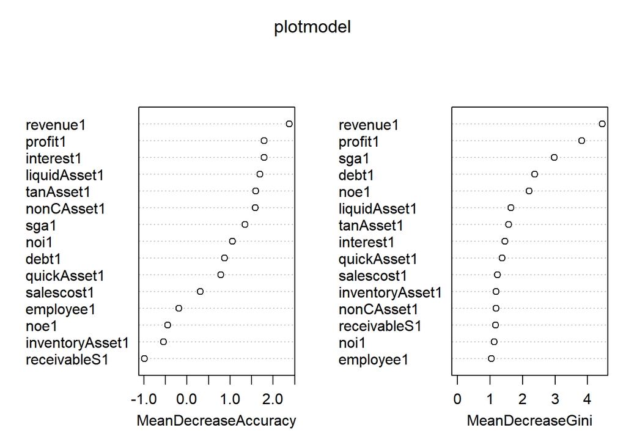

```r
imp <- varImpPlot(plotmodel)
```

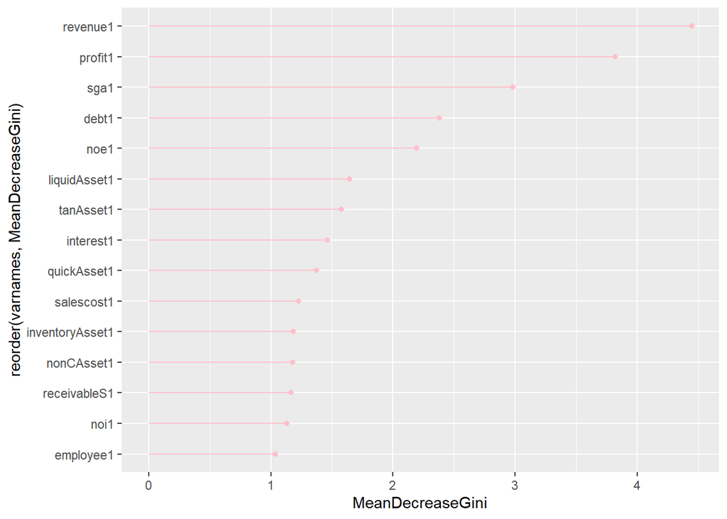

```r
imp <- as.data.frame(imp)
imp$varnames <- rownames(imp)
rownames(imp) <- NULL


ggplot(imp, aes(x = reorder(varnames, MeanDecreaseGini), y = MeanDecreaseGini), colors = "pink") +
  geom_point(color = "pink") +
  geom_segment(aes(x=varnames, xend = varnames, y = 0, yend = MeanDecreaseGini), color = "pink") +
  coord_flip()
```

# Chpater3. 회귀모델

### 문제 1. Boston 데이터를 8:2로 train과 test set으로 나누세요. (p: 0.2)

```r
library(MASS)
bos <- as.data.frame(MASS::Boston)

set.seed(1234)
test_index <- createDataPartition(
  bos$medv, p = 0.2, list = FALSE)

bos_test_data <- bos[test_index,]
bos_train_data <- bos[-test_index,]
```

### 문제 2. expand.grid를 이용하여 다음과 같은 데이터 프레임을 만드세요. (데이터 프레임 명: RMSE_rf)

```r
RMSE_rf <- expand.grid(mtry = c(3,4,5), ntree = c(10,100,200), RMSE = NA)
RMSE_rf
```

```
##   mtry ntree RMSE
## 1    3    10   NA
## 2    4    10   NA
## 3    5    10   NA
## 4    3   100   NA
## 5    4   100   NA
## 6    5   100   NA
## 7    3   200   NA
## 8    4   200   NA
## 9    5   200   NA
```

### 문제 3. medv를 종속변수로 하는 랜덤포레스트에 대한 5-fold CV 그리드서치를 진행하여 RMSE_rf의 RMSE 변수에 해당 RMSE값을 넣으세요. (이중 for문을 이용하여 직접 코드를 짤 것)

```r
bos_folds <- createFolds(bos$medv, k=5)


for(i in 1:nrow(RMSE_rf)){
  cvacc2 <- NULL
  for(k in 1:5){
    cv_train2 = bos[-bos_folds[[k]],]
    cv_test2 = bos[bos_folds[[k]],]

    mymodel2 <- randomForest(medv ~ ., mtry = RMSE_rf[i,1], data = cv_train2, ntree = RMSE_rf[i,2])

    pred2 <- predict(mymodel2,cv_test2)
    cvacc2[k]<- RMSE(cv_test2$medv, pred2)
  }
  RMSE_rf[i,3] <- mean(cvacc2)
}
```

### 문제 4. RMSE_rf에서 가장 낮은 RMSE값을 가진 행을 출력하세요.

```r
RMSE_rf %>%
  filter(RMSE == min(RMSE))
```

```
##   mtry ntree     RMSE
## 1    5   200 3.348298
```

### 문제 5. train set으로 그리드 서치로 나온 가장 좋은 조합의 파라미터의 랜덤포레스트를 학습시킨 후, test set의 RMSE를 구하세요.

```r
last_model <- randomForest(medv ~., mtry = 5, ntree = 200, data = bos_train_data)

prediction <- predict(last_model,bos_test_data)
RMSE(bos_test_data$medv, prediction)
```

```
## [1] 4.040333
```